```python
# To enable plotting graphs in Jupyter notebook
%matplotlib inline
import numpy as np
import pandas as pd
from sklearn.model_selection import train_test_split
from sklearn.neighbors import KNeighborsClassifier
from scipy.stats import zscore
from sklearn.metrics import classification_report
from sklearn.metrics import roc_auc_score
from sklearn.model_selection import GridSearchCV
import seaborn as sns
import matplotlib.pyplot as plt
```

# A. Read all the 3 CSV files as DataFrame and store them into 3 separate variables.

```python
p1 = pd.read_csv("Part1+-+Normal.csv")
```

```python
p2= pd.read_csv("Part1+-+Type_H.csv")
```

```python
p3= pd.read_csv('Part1+-+Type_S.csv')
```

# B. Print Shape and columns of all the 3 DataFrames.

```python
p = [p1, p2,p3]

for df in p:
    print(df.shape)
```

```
(100, 7)
(60, 7)
(150, 7)
```

# D. Print DataTypes of all the 3 DataFrames.

```python
p = [p1, p2,p3]

for df in p:
    print(df.dtypes)
```

```
P_incidence    float64
P_tilt         float64
L_angle        float64
S_slope        float64
P_radius       float64
S_Degree       float64
Class           object
dtype: object
P_incidence    float64
P_tilt         float64
L_angle        float64
S_slope        float64
P_radius       float64
S_Degree       float64
Class           object
dtype: object
P_incidence    float64
P_tilt         float64
L_angle        float64
S_slope        float64
P_radius       float64
S_Degree       float64
Class           object
dtype: object
```

# C. Compare Column names of all the 3 DataFrames and clearly write observations.

```python
np.all([sorted(p[0].columns) == sorted(i.columns) for i in p])
```

```
True
```

it is indicating the all the columns names in all 3 data sets are same

```python
p1.head()
```

|  | P_incidence | P_tilt | L_angle | S_slope | P_radius | S_Degree | Class |
| --- | --- | --- | --- | --- | --- | --- | --- |
| 0 | 38.505273 | 16.964297 | 35.112814 | 21.540976 | 127.632875 | 7.986683 | Normal |
| 1 | 54.920858 | 18.968430 | 51.601455 | 35.952428 | 125.846646 | 2.001642 | Normal |
| 2 | 44.362490 | 8.945435 | 46.902096 | 35.417055 | 129.220682 | 4.994195 | Normal |
| 3 | 48.318931 | 17.452121 | 48.000000 | 30.866809 | 128.980308 | -0.910941 | Normal |
| 4 | 45.701789 | 10.659859 | 42.577846 | 35.041929 | 130.178314 | -3.388910 | Normal |

```python
p2.head()
```

|  | P_incidence | P_tilt | L_angle | S_slope | P_radius | S_Degree | Class |
| --- | --- | --- | --- | --- | --- | --- | --- |
| 0 | 63.027817 | 22.552586 | 39.609117 | 40.475232 | 98.672917 | -0.254400 | Type_H |
| 1 | 39.056951 | 10.060991 | 25.015378 | 28.995960 | 114.405425 | 4.564259 | Type_H |
| 2 | 68.832021 | 22.218482 | 50.092194 | 46.613539 | 105.985135 | -3.530317 | Type_H |
| 3 | 69.297008 | 24.652878 | 44.311238 | 44.644130 | 101.868495 | 11.211523 | Type_H |
| 4 | 49.712859 | 9.652075 | 28.317406 | 40.060784 | 108.168725 | 7.918501 | Type_H |

```python
p3.head()
```

|  | P_incidence | P_tilt | L_angle | S_slope | P_radius | S_Degree | Class |
| --- | --- | --- | --- | --- | --- | --- | --- |
| 0 | 74.377678 | 32.053104 | 78.772013 | 42.324573 | 143.560690 | 56.125906 | Type_S |
| 1 | 89.680567 | 32.704435 | 83.130732 | 56.976132 | 129.955476 | 92.027277 | Type_S |
| 2 | 44.529051 | 9.433234 | 52.000000 | 35.095817 | 134.711772 | 29.106575 | Type_S |
| 3 | 77.690577 | 21.380645 | 64.429442 | 56.309932 | 114.818751 | 26.931841 | Type_S |
| 4 | 76.147212 | 21.936186 | 82.961502 | 54.211027 | 123.932010 | 10.431972 | Type_S |

# E.Observe and share variation in ‘Class’ feature of all the 3 DaraFrames.

```python
p1['Class'].unique()
```

```
array(['Normal', 'Nrmal'], dtype=object)
```

```python
p2['Class'].unique()
```

```
array(['Type_H', 'type_h'], dtype=object)
```

```python
p3['Class'].unique()
```

```
array(['Type_S', 'tp_s'], dtype=object)
```

feature class having the object type and others datatype as float 64 post merging.

# 2.A. Unify all the variations in ‘Class’ feature for all the 3 DataFrames.

```python
p1["Class"] = p1["Class"].apply(lambda x: x.replace("Nrmal", "Normal"))
```

```python
p1.head()
```

|  | P_incidence | P_tilt | L_angle | S_slope | P_radius | S_Degree | Class |
| --- | --- | --- | --- | --- | --- | --- | --- |
| 0 | 38.505273 | 16.964297 | 35.112814 | 21.540976 | 127.632875 | 7.986683 | Normal |
| 1 | 54.920858 | 18.968430 | 51.601455 | 35.952428 | 125.846646 | 2.001642 | Normal |
| 2 | 44.362490 | 8.945435 | 46.902096 | 35.417055 | 129.220682 | 4.994195 | Normal |
| 3 | 48.318931 | 17.452121 | 48.000000 | 30.866809 | 128.980308 | -0.910941 | Normal |
| 4 | 45.701789 | 10.659859 | 42.577846 | 35.041929 | 130.178314 | -3.388910 | Normal |

```python
p2["Class"] = p2["Class"].apply(lambda x: x.replace("type_h", "Type_H"))
```

```python
p2.head()
```

|  | P_incidence | P_tilt | L_angle | S_slope | P_radius | S_Degree | Class |
| --- | --- | --- | --- | --- | --- | --- | --- |
| 0 | 63.027817 | 22.552586 | 39.609117 | 40.475232 | 98.672917 | -0.254400 | Type_H |
| 1 | 39.056951 | 10.060991 | 25.015378 | 28.995960 | 114.405425 | 4.564259 | Type_H |
| 2 | 68.832021 | 22.218482 | 50.092194 | 46.613539 | 105.985135 | -3.530317 | Type_H |
| 3 | 69.297008 | 24.652878 | 44.311238 | 44.644130 | 101.868495 | 11.211523 | Type_H |
| 4 | 49.712859 | 9.652075 | 28.317406 | 40.060784 | 108.168725 | 7.918501 | Type_H |

```python
p3["Class"] = p3["Class"].apply(lambda x: x.replace("tp_s", "Type_S"))
```

```python
p3.head()
```

|  | P_incidence | P_tilt | L_angle | S_slope | P_radius | S_Degree | Class |
| --- | --- | --- | --- | --- | --- | --- | --- |
| 0 | 74.377678 | 32.053104 | 78.772013 | 42.324573 | 143.560690 | 56.125906 | Type_S |
| 1 | 89.680567 | 32.704435 | 83.130732 | 56.976132 | 129.955476 | 92.027277 | Type_S |
| 2 | 44.529051 | 9.433234 | 52.000000 | 35.095817 | 134.711772 | 29.106575 | Type_S |
| 3 | 77.690577 | 21.380645 | 64.429442 | 56.309932 | 114.818751 | 26.931841 | Type_S |
| 4 | 76.147212 | 21.936186 | 82.961502 | 54.211027 | 123.932010 | 10.431972 | Type_S |

# 2.B. Combine all the 3 DataFrames to form a single DataFrame

```python
p_comb = pd.concat([p1,p2,p3])
```

```python
print(p_comb)
```

```
     P_incidence     P_tilt    L_angle    S_slope    P_radius    S_Degree  \
0      38.505273  16.964297  35.112814  21.540976  127.632875    7.986683
1      54.920858  18.968430  51.601455  35.952428  125.846646    2.001642
2      44.362490   8.945435  46.902096  35.417055  129.220682    4.994195
3      48.318931  17.452121  48.000000  30.866809  128.980308   -0.910941
4      45.701789  10.659859  42.577846  35.041929  130.178314   -3.388910
..           ...        ...        ...        ...         ...         ...
145    80.111572  33.942432  85.101608  46.169139  125.593624  100.292107
146    95.480229  46.550053  59.000000  48.930176   96.683903   77.283072
147    74.094731  18.823727  76.032156  55.271004  128.405731   73.388216
148    87.679087  20.365613  93.822416  67.313473  120.944829   76.730629
149    48.259920  16.417462  36.329137  31.842457   94.882336   28.343799

      Class
0    Normal
1    Normal
2    Normal
3    Normal
4    Normal
..      ...
145  Type_S
146  Type_S
147  Type_S
148  Type_S
149  Type_S

[310 rows x 7 columns]
```

```python
p_comb.shape
```

```
(310, 7)
```

```python
p_comb.dtypes
```

```
P_incidence    float64
P_tilt         float64
L_angle        float64
S_slope        float64
P_radius       float64
S_Degree       float64
Class           object
dtype: object
```

# 2.C. Print 5 random samples of this DataFrame

```python
p_comb.sample(n=5)
```

|  | P_incidence | P_tilt | L_angle | S_slope | P_radius | S_Degree | Class |
| --- | --- | --- | --- | --- | --- | --- | --- |
| 39 | 52.419385 | 19.011561 | 35.872660 | 33.407825 | 116.559771 | 1.694705 | Type_H |
| 101 | 67.263149 | 7.194661 | 51.696887 | 60.068488 | 97.801085 | 42.136943 | Type_S |
| 28 | 56.605771 | 16.800200 | 42.000000 | 39.805571 | 127.294522 | 24.018575 | Type_S |
| 21 | 74.005541 | 21.122402 | 57.379502 | 52.883139 | 120.205963 | 74.555166 | Type_S |
| 86 | 85.581710 | 30.457039 | 78.231379 | 55.124672 | 114.866049 | 68.376122 | Type_S |

# 2.D. Print Feature-wise percentage of Null values.

```python
p_comb.isnull().sum().sum()/len(p_comb) # no. of null values in whole dataset
```

```
0.0
```

```python
p_comb.isnull().sum()/len(p_comb)# no.ofnull values in column wise manner
```

```
P_incidence    0.0
P_tilt         0.0
L_angle        0.0
S_slope        0.0
P_radius       0.0
S_Degree       0.0
Class          0.0
dtype: float64
```

# 2.E. Check 5-point summary of the new DataFrame.

```python
p_new=p_comb.describe()
```

```python
p_new.tail(5) # five point summury of newly created dataset
```

|  | P_incidence | P_tilt | L_angle | S_slope | P_radius | S_Degree |
| --- | --- | --- | --- | --- | --- | --- |
| min | 26.147921 | -6.554948 | 14.000000 | 13.366931 | 70.082575 | -11.058179 |
| 25% | 46.430294 | 10.667069 | 37.000000 | 33.347122 | 110.709196 | 1.603727 |
| 50% | 58.691038 | 16.357689 | 49.562398 | 42.404912 | 118.268178 | 11.767934 |
| 75% | 72.877696 | 22.120395 | 63.000000 | 52.695888 | 125.467674 | 41.287352 |
| max | 129.834041 | 49.431864 | 125.742385 | 121.429566 | 163.071041 | 418.543082 |

# 3A. Visualize a heatmap to understand correlation between all features

```python
p_comb.corr()
```

|  | P_incidence | P_tilt | L_angle | S_slope | P_radius | S_Degree |
| --- | --- | --- | --- | --- | --- | --- |
| P_incidence | 1.000000 | 0.629199 | 0.717282 | 0.814960 | -0.247467 | 0.638743 |
| P_tilt | 0.629199 | 1.000000 | 0.432764 | 0.062345 | 0.032668 | 0.397862 |
| L_angle | 0.717282 | 0.432764 | 1.000000 | 0.598387 | -0.080344 | 0.533667 |
| S_slope | 0.814960 | 0.062345 | 0.598387 | 1.000000 | -0.342128 | 0.523557 |
| P_radius | -0.247467 | 0.032668 | -0.080344 | -0.342128 | 1.000000 | -0.026065 |
| S_Degree | 0.638743 | 0.397862 | 0.533667 | 0.523557 | -0.026065 | 1.000000 |

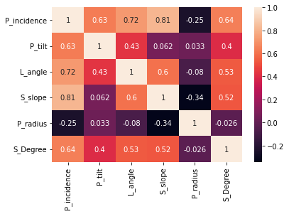

```python
import seaborn as sns

sns.heatmap(p_comb.corr(),annot=True)
```

# 3C. Visualize a pairplot with 3 classes distinguished by colors and share insights.

```python
p_comb.index.is_unique  # pair plot can not be plotted because reindexing in not possible if index of dataset duplicated
```

```
False
```

```python
p_comb.index.duplicated()# find out the duplicated index value
```

```
array([False, False, False, False, False, False, False, False, False,
       False, False, False, False, False, False, False, False, False,
       False, False, False, False, False, False, False, False, False,
       False, False, False, False, False, False, False, False, False,
       False, False, False, False, False, False, False, False, False,
       False, False, False, False, False, False, False, False, False,
       False, False, False, False, False, False, False, False, False,
       False, False, False, False, False, False, False, False, False,
       False, False, False, False, False, False, False, False, False,
       False, False, False, False, False, False, False, False, False,
       False, False, False, False, False, False, False, False, False,
       False,  True,  True,  True,  True,  True,  True,  True,  True,
        True,  True,  True,  True,  True,  True,  True,  True,  True,
        True,  True,  True,  True,  True,  True,  True,  True,  True,
        True,  True,  True,  True,  True,  True,  True,  True,  True,
        True,  True,  True,  True,  True,  True,  True,  True,  True,
        True,  True,  True,  True,  True,  True,  True,  True,  True,
        True,  True,  True,  True,  True,  True,  True,  True,  True,
        True,  True,  True,  True,  True,  True,  True,  True,  True,
        True,  True,  True,  True,  True,  True,  True,  True,  True,
        True,  True,  True,  True,  True,  True,  True,  True,  True,
        True,  True,  True,  True,  True,  True,  True,  True,  True,
        True,  True,  True,  True,  True,  True,  True,  True,  True,
        True,  True,  True,  True,  True,  True,  True,  True,  True,
        True,  True,  True,  True,  True,  True,  True,  True,  True,
        True,  True,  True,  True,  True,  True,  True,  True,  True,
        True,  True,  True,  True,  True,  True,  True,  True,  True,
        True,  True,  True,  True,  True,  True,  True,  True,  True,
        True,  True,  True,  True,  True,  True,  True,  True, False,
       False, False, False, False, False, False, False, False, False,
       False, False, False, False, False, False, False, False, False,
       False, False, False, False, False, False, False, False, False,
       False, False, False, False, False, False, False, False, False,
       False, False, False, False, False, False, False, False, False,
       False, False, False, False])
```

```python
p_comb.reset_index(level=0, inplace=True) # substituting the with new index to avoid the duplicated enteries in index
```

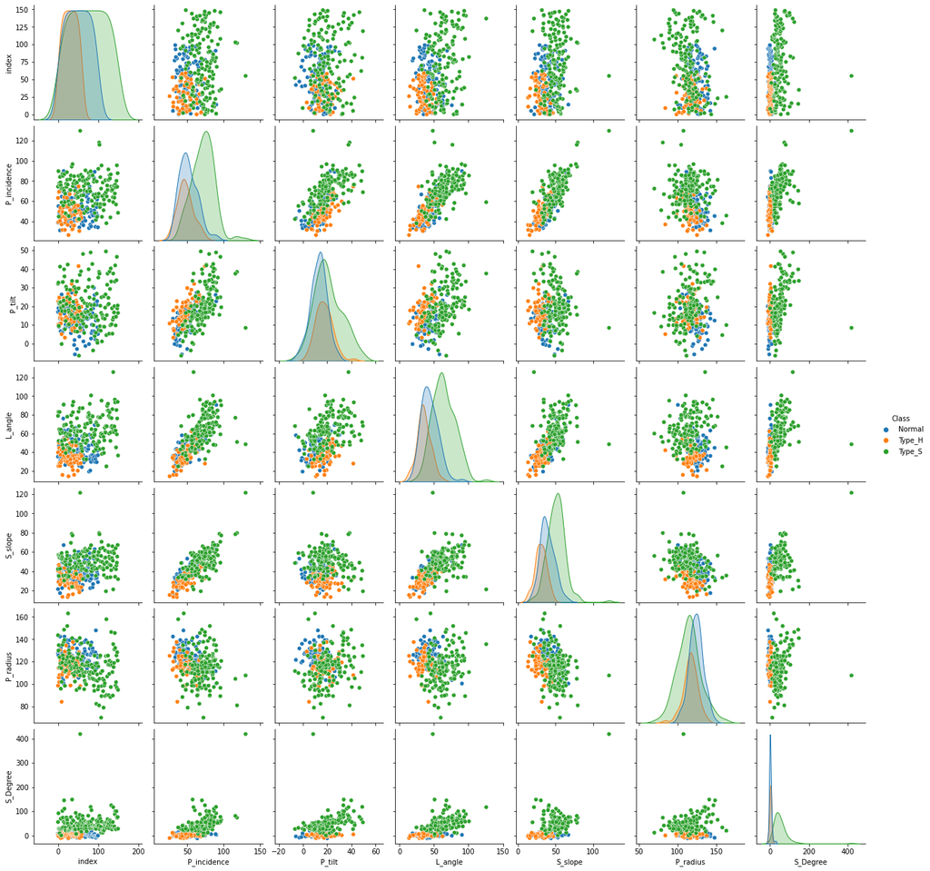

```python
sns.pairplot(p_comb, hue= 'Class') # visulize in the form of pairplot
plt.show()
```

1. type S data showing more spread as compared to type H and normal. 2. p incident is highly correlted with p_tilt, L_angle and S_slope 3. P_incidence, S-Slope and p_raidus seems to be more approprite choice for target varialbe rathen than S_degree, L_angle and S_degree.

```
C:\Users\nav deepak\AppData\Local\Programs\Python\Python310\lib\site-packages\seaborn\_decorators.py:36: FutureWarning: Pass the following variables as keyword args: x, y. From version 0.12, the only valid positional argument will be `data`, and passing other arguments without an explicit keyword wi…
  warnings.warn(
```

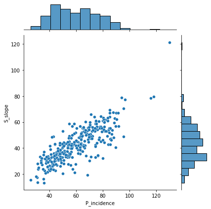

```python
#D. Visualize a jointplot for ‘P_incidence’ and ‘S_slope’ and share insights
sns.jointplot(p_comb['P_incidence'],p_comb['S_slope'])
```

S_slope and P_incedent showing the high correlation.

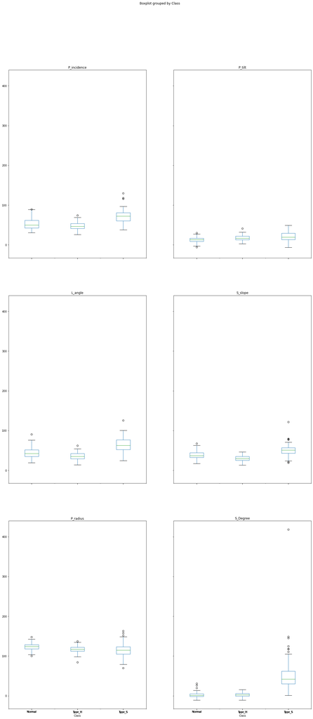

```python
#E. Visualize a boxplot to check distribution of the features and share insights.
p_comb.boxplot(column=['P_incidence', 'P_tilt', 'L_angle', 'S_slope', 'P_radius','S_Degree'], grid= False, figsize= (20,45), by= 'Class')
plt.show()
```

in p_incedence box plot, type s has more outliers in p_tilt box plot, normal has more outliers in L_angle box plot, all having the same no. fo outliers in S_slope box plot, type s has more outliers in p_radius box plot, type s has more outliers in S_degree box plot, type s has more outliers in conclusion, type S cancer has showing more deviation from normal, this needs to keep in mind while designing the ML model # 4. Model Building: [6 Marks] A. Split data into X and Y. [1 Marks] B. Split data into train and test with 80:20 proportion. [1 Marks] C. Train a Supervised Learning Classification base model using KNN classifier. [2 Marks] D. Print all the possible performance metrics for both train and test data. [2 Marks]

```python
# The first column is id column which is patient id and nothing to do with the model attriibutes. So drop it.

p_comb = p_comb.drop(labels = "index", axis = 1)
```

```python
# Create a separate dataframe consisting only of the features i.e independent attributes
# question no. 4: Split data into X and Y.

X = p_comb.drop(labels= "Class" , axis = 1)
y = p_comb["Class"]
X.head()
```

|  | P_incidence | P_tilt | L_angle | S_slope | P_radius | S_Degree |
| --- | --- | --- | --- | --- | --- | --- |
| 0 | 38.505273 | 16.964297 | 35.112814 | 21.540976 | 127.632875 | 7.986683 |
| 1 | 54.920858 | 18.968430 | 51.601455 | 35.952428 | 125.846646 | 2.001642 |
| 2 | 44.362490 | 8.945435 | 46.902096 | 35.417055 | 129.220682 | 4.994195 |
| 3 | 48.318931 | 17.452121 | 48.000000 | 30.866809 | 128.980308 | -0.910941 |
| 4 | 45.701789 | 10.659859 | 42.577846 | 35.041929 | 130.178314 | -3.388910 |

```python
# convert the features into z scores as we do not know what units / scales were used and store them in new dataframe
# It is always adviced to scale numeric attributes in models that calculate distances.

XScaled  = X.apply(zscore)  # convert all attributes to Z scale

XScaled.describe()
```

|  | P_incidence | P_tilt | L_angle | S_slope | P_radius | S_Degree |
| --- | --- | --- | --- | --- | --- | --- |
| count | 3.100000e+02 | 3.100000e+02 | 3.100000e+02 | 3.100000e+02 | 3.100000e+02 | 3.100000e+02 |
| mean | -1.375244e-16 | 2.292073e-16 | 1.833659e-16 | -1.833659e-16 | -6.876220e-16 | -4.584147e-17 |
| std | 1.001617e+00 | 1.001617e+00 | 1.001617e+00 | 1.001617e+00 | 1.001617e+00 | 1.001617e+00 |
| min | -1.996010e+00 | -2.411664e+00 | -2.047652e+00 | -2.207741e+00 | -3.597963e+00 | -9.961725e-01 |
| 25% | -8.173982e-01 | -6.881138e-01 | -8.060267e-01 | -7.168418e-01 | -5.423830e-01 | -6.585073e-01 |
| 50% | -1.049246e-01 | -1.186061e-01 | -1.278621e-01 | -4.095971e-02 | 2.613767e-02 | -3.874502e-01 |
| 75% | 7.194643e-01 | 4.581158e-01 | 5.975493e-01 | 7.269414e-01 | 5.676209e-01 | 3.997679e-01 |
| max | 4.029206e+00 | 3.191402e+00 | 3.984615e+00 | 5.855771e+00 | 3.395818e+00 | 1.046035e+01 |

```python
XScaled.shape
```

```
(310, 6)
```

```python
# Split X and y into training and test set in 80:20 ratio

X_train, X_test, y_train, y_test = train_test_split(XScaled, y, test_size=0.20, random_state=1)
```

```python
 #Train a Supervised Learning Classification base model using KNN classifier.

knn = KNeighborsClassifier(n_neighbors= 5 , weights = 'distance', leaf_size=30, p=2) # default values of n_neighbors, p and leaf_size taken into consideration
```

```python
# Call Nearest Neighbour algorithm

knn.fit(X_train, y_train)
```

```
KNeighborsClassifier(weights='distance')
```

```python
knn.score(X_train, y_train)
```

```
1.0
```

```python
# For every test data point, predict it's label based on 5 nearest neighbours in this model. The majority class will
# be assigned to the test data point

predicted_labels = knn.predict(X_test)
knn.score(X_test, y_test)
```

```
0.7258064516129032
```

```
Confusion Matrix
```

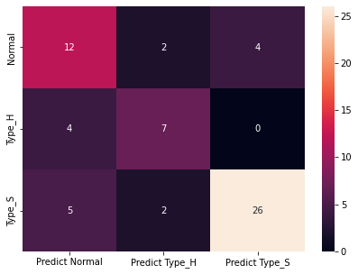

```python
# calculate accuracy measures and confusion matrix
from sklearn import metrics

print("Confusion Matrix")
cm=metrics.confusion_matrix(y_test, predicted_labels, labels=['Normal', 'Type_H', 'Type_S' ])

df_cm = pd.DataFrame(cm, index = [i for i in ['Normal','Type_H','Type_S']],
                  columns = [i for i in ['Predict Normal','Predict Type_H','Predict Type_S']])
plt.figure(figsize = (7,5))
sns.heatmap(df_cm, annot=True)
```

```python
print("Classification Report")
print(metrics.classification_report(y_test, predicted_labels, labels=['Normal', 'Type_H', 'Type_S']))
```

```
Classification Report
              precision    recall  f1-score   support

      Normal       0.57      0.67      0.62        18
      Type_H       0.64      0.64      0.64        11
      Type_S       0.87      0.79      0.83        33

    accuracy                           0.73        62
   macro avg       0.69      0.70      0.69        62
weighted avg       0.74      0.73      0.73        62
```

```python
scores=[]
for k in range(1,50):
    knn= KNeighborsClassifier(n_neighbors= k, weights= 'distance')
    knn.fit(X_train, y_train)
    scores.append(knn.score(X_test, y_test))
```

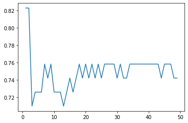

```python
plt.plot(range(1,50),scores)
```

```python
#List Hyperparameters that we want to tune.
leaf_size = list(range(1,50))
n_neighbors = list(range(1,30))
p=[1,2]
weights= ['uniform', 'distance']

#Convert to dictionary
hyperparameters = dict(leaf_size=leaf_size, n_neighbors=n_neighbors, p=p, weights= weights)
#Create new KNN object
knn_2 = KNeighborsClassifier()
#Use GridSearch
clf = GridSearchCV(knn_2, hyperparameters, cv=10)
#Fit the model
best_model = clf.fit(XScaled,y)
#Print The value of best Hyperparameters
print('Best leaf_size:', best_model.best_estimator_.get_params()['leaf_size'])
print('Best p:', best_model.best_estimator_.get_params()['p'])
print('Best n_neighbors:', best_model.best_estimator_.get_params()['n_neighbors'])
print('Best weights:', best_model.best_estimator_.get_params()['weights'])
```

```
Best leaf_size: 1
Best p: 1
Best n_neighbors: 17
Best weights: distance
```

```python
knn_3= KNeighborsClassifier(n_neighbors=17, weights='distance', algorithm='auto', leaf_size=1, p=1, metric='minkowski', metric_params=None, n_jobs=None)
```

```python
knn_3.fit(X_train, y_train)
```

```
KNeighborsClassifier(leaf_size=1, n_neighbors=17, p=1, weights='distance')
```

```python
knn_3.score(X_train, y_train)
```

```
1.0
```

```python
predicted_labels = knn_3.predict(X_test)
knn_3.score(X_test, y_test)
```

```
0.7419354838709677
```

```
Confusion Matrix_2
```

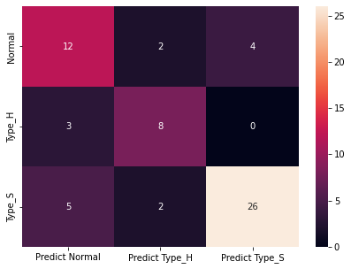

```python
print("Confusion Matrix_2")
cm=metrics.confusion_matrix(y_test, predicted_labels, labels=['Normal', 'Type_H', 'Type_S' ])

df_cm = pd.DataFrame(cm, index = [i for i in ['Normal','Type_H','Type_S']],
                  columns = [i for i in ['Predict Normal','Predict Type_H','Predict Type_S']])
plt.figure(figsize = (7,5))
sns.heatmap(df_cm, annot=True)
```

```python
print("Classification Report 2")
print(metrics.classification_report(y_test, predicted_labels, labels=['Normal', 'Type_H', 'Type_S']))
```

```
Classification Report 2
              precision    recall  f1-score   support

      Normal       0.60      0.67      0.63        18
      Type_H       0.67      0.73      0.70        11
      Type_S       0.87      0.79      0.83        33

    accuracy                           0.74        62
   macro avg       0.71      0.73      0.72        62
weighted avg       0.75      0.74      0.75        62
```

accuracy of model improved from 73 to 74 % after tuning the hyper parameters, by changing the value of n_neighbours to 17. model precision also improved as shown from the calssification matrix

```python
#PART B
# PROJECT OBJECTIVE: Build a Machine Learning model to perform focused marketing by predicting the potential customers
#who will convert
#using the historical dataset.
```

```python
#1A. Read both the Datasets ‘Data1’ and ‘Data 2’ as DataFrame and store them into two separate variables.
b1= pd.read_csv('Part2+-+Data1.csv')
```

```python
b2= pd.read_csv('Part2+-Data2.csv')
```

```python
b1.head()
```

|  | ID | Age | CustomerSince | HighestSpend | ZipCode | HiddenScore | MonthlyAverageSpend | Level |
| --- | --- | --- | --- | --- | --- | --- | --- | --- |
| 0 | 1 | 25 | 1 | 49 | 91107 | 4 | 1.6 | 1 |
| 1 | 2 | 45 | 19 | 34 | 90089 | 3 | 1.5 | 1 |
| 2 | 3 | 39 | 15 | 11 | 94720 | 1 | 1.0 | 1 |
| 3 | 4 | 35 | 9 | 100 | 94112 | 1 | 2.7 | 2 |
| 4 | 5 | 35 | 8 | 45 | 91330 | 4 | 1.0 | 2 |

```python
b2.head()
```

|  | ID | Mortgage | Security | FixedDepositAccount | InternetBanking | CreditCard | LoanOnCard |
| --- | --- | --- | --- | --- | --- | --- | --- |
| 0 | 1 | 0 | 1 | 0 | 0 | 0 | NaN |
| 1 | 2 | 0 | 1 | 0 | 0 | 0 | NaN |
| 2 | 3 | 0 | 0 | 0 | 0 | 0 | NaN |
| 3 | 4 | 0 | 0 | 0 | 0 | 0 | NaN |
| 4 | 5 | 0 | 0 | 0 | 0 | 1 | NaN |

```python
#2B. Print shape and Column Names and DataTypes of both the Dataframes.p = [p1, p2,p3]
b= [b1, b2]
for df in b:
    print(df.shape)
```

```
(5000, 8)
(5000, 7)
```

```python
b= [b1, b2]
for df in b:
    print(df.columns)
```

```
Index(['ID', 'Age', 'CustomerSince', 'HighestSpend', 'ZipCode', 'HiddenScore',
       'MonthlyAverageSpend', 'Level'],
      dtype='object')
Index(['ID', 'Mortgage', 'Security', 'FixedDepositAccount', 'InternetBanking',
       'CreditCard', 'LoanOnCard'],
      dtype='object')
```

```python
for df in b:
    print(df.dtypes)
```

```
ID                       int64
Age                      int64
CustomerSince            int64
HighestSpend             int64
ZipCode                  int64
HiddenScore              int64
MonthlyAverageSpend    float64
Level                    int64
dtype: object
ID                       int64
Mortgage                 int64
Security                 int64
FixedDepositAccount      int64
InternetBanking          int64
CreditCard               int64
LoanOnCard             float64
dtype: object
```

```python
#1C. Merge both the Dataframes on ‘ID’ feature to form a single DataFrame
b_merg= pd.merge(b1, b2, on='ID')
b_merg
```

|  | ID | Age | CustomerSince | HighestSpend | ZipCode | HiddenScore | MonthlyAverageSpend | Level | Mortgage | Security | FixedDepositAccount | InternetBanking | CreditCard | LoanOnCard |
| --- | --- | --- | --- | --- | --- | --- | --- | --- | --- | --- | --- | --- | --- | --- |
| 0 | 1 | 25 | 1 | 49 | 91107 | 4 | 1.6 | 1 | 0 | 1 | 0 | 0 | 0 | NaN |
| 1 | 2 | 45 | 19 | 34 | 90089 | 3 | 1.5 | 1 | 0 | 1 | 0 | 0 | 0 | NaN |
| 2 | 3 | 39 | 15 | 11 | 94720 | 1 | 1.0 | 1 | 0 | 0 | 0 | 0 | 0 | NaN |
| 3 | 4 | 35 | 9 | 100 | 94112 | 1 | 2.7 | 2 | 0 | 0 | 0 | 0 | 0 | NaN |
| 4 | 5 | 35 | 8 | 45 | 91330 | 4 | 1.0 | 2 | 0 | 0 | 0 | 0 | 1 | NaN |
| ... | ... | ... | ... | ... | ... | ... | ... | ... | ... | ... | ... | ... | ... | ... |
| 4995 | 4996 | 29 | 3 | 40 | 92697 | 1 | 1.9 | 3 | 0 | 0 | 0 | 1 | 0 | 0.0 |
| 4996 | 4997 | 30 | 4 | 15 | 92037 | 4 | 0.4 | 1 | 85 | 0 | 0 | 1 | 0 | 0.0 |
| 4997 | 4998 | 63 | 39 | 24 | 93023 | 2 | 0.3 | 3 | 0 | 0 | 0 | 0 | 0 | 0.0 |
| 4998 | 4999 | 65 | 40 | 49 | 90034 | 3 | 0.5 | 2 | 0 | 0 | 0 | 1 | 0 | 0.0 |
| 4999 | 5000 | 28 | 4 | 83 | 92612 | 3 | 0.8 | 1 | 0 | 0 | 0 | 1 | 1 | 0.0 |

5000 rows × 14 columns

```python
b_merg.dtypes
```

```
ID                       int64
Age                      int64
CustomerSince            int64
HighestSpend             int64
ZipCode                  int64
HiddenScore              int64
MonthlyAverageSpend    float64
Level                    int64
Mortgage                 int64
Security                 int64
FixedDepositAccount      int64
InternetBanking          int64
CreditCard               int64
LoanOnCard             float64
dtype: object
```

```python
#1D. Change Datatype of below features to ‘Object’
#CreditCard’, ‘InternetBanking’, ‘FixedDepositAccount’, ‘Security’, ‘Level’, ‘HiddenScore’.
b_merg = b_merg.astype({'CreditCard': 'object', 'InternetBanking': 'object', 'FixedDepositAccount': 'object', 'Security':'object', 'Level':'object', 'HiddenScore':'object'})
b_merg.dtypes
```

```
ID                       int64
Age                      int64
CustomerSince            int64
HighestSpend             int64
ZipCode                  int64
HiddenScore             object
MonthlyAverageSpend    float64
Level                   object
Mortgage                 int64
Security                object
FixedDepositAccount     object
InternetBanking         object
CreditCard              object
LoanOnCard             float64
dtype: object
```

2. Data Exploration and Analysis: [5 Marks] A. Visualize distribution of Target variable ‘LoanOnCard’ and clearly share insights. [2 Marks] B. Check the percentage of missing values and impute if required. [1 Marks] C. Check for unexpected values in each categorical variable and impute with best suitable value. [2 Marks]

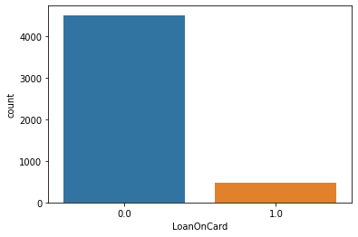

```python
 #Visualize distribution of Target variable ‘LoanOnCard’ and clearly share insights.
sns.countplot(x ='LoanOnCard', data = b_merg)
```

```python
# Check the percentage of missing values and impute if required
percent_missing= b_merg.isnull().sum()*100/len(b_merg)
print(percent_missing)
```

```
ID                     0.0
Age                    0.0
CustomerSince          0.0
HighestSpend           0.0
ZipCode                0.0
HiddenScore            0.0
MonthlyAverageSpend    0.0
Level                  0.0
Mortgage               0.0
Security               0.0
FixedDepositAccount    0.0
InternetBanking        0.0
CreditCard             0.0
LoanOnCard             0.4
dtype: float64
```

```python
medianFiller = lambda x: x.fillna(0)
b_merg = b_merg.apply(medianFiller,axis=0)
b_merg.head(5)
```

|  | ID | Age | CustomerSince | HighestSpend | ZipCode | HiddenScore | MonthlyAverageSpend | Level | Mortgage | Security | FixedDepositAccount | InternetBanking | CreditCard | LoanOnCard |
| --- | --- | --- | --- | --- | --- | --- | --- | --- | --- | --- | --- | --- | --- | --- |
| 0 | 1 | 25 | 1 | 49 | 91107 | 4 | 1.6 | 1 | 0 | 1 | 0 | 0 | 0 | 0.0 |
| 1 | 2 | 45 | 19 | 34 | 90089 | 3 | 1.5 | 1 | 0 | 1 | 0 | 0 | 0 | 0.0 |
| 2 | 3 | 39 | 15 | 11 | 94720 | 1 | 1.0 | 1 | 0 | 0 | 0 | 0 | 0 | 0.0 |
| 3 | 4 | 35 | 9 | 100 | 94112 | 1 | 2.7 | 2 | 0 | 0 | 0 | 0 | 0 | 0.0 |
| 4 | 5 | 35 | 8 | 45 | 91330 | 4 | 1.0 | 2 | 0 | 0 | 0 | 0 | 1 | 0.0 |

```python
 #Check for unexpected values in each categorical variable and impute with best suitable value
b_merg['LoanOnCard'].unique()
```

```
array([0., 1.])
```

```python
b_merg['Security'].unique()
```

```
array([1, 0], dtype=int64)
```

```python
b_merg['CreditCard'].unique()
```

```
array([0, 1], dtype=int64)
```

```python
b_merg['InternetBanking'].unique()
```

```
array([0, 1], dtype=int64)
```

```python
b_merg['FixedDepositAccount'].unique()
```

```
array([0, 1], dtype=int64)
```

```python
b_merg.corr()['LoanOnCard']
```

```
ID                    -0.024801
Age                   -0.007726
CustomerSince         -0.007413
HighestSpend           0.502462
ZipCode                0.000107
HiddenScore            0.061367
MonthlyAverageSpend    0.366889
Level                  0.136722
Mortgage               0.142095
Security               0.021954
FixedDepositAccount    0.316355
InternetBanking        0.006278
CreditCard             0.002802
LoanOnCard             1.000000
Name: LoanOnCard, dtype: float64
```

Data Preparation and model building: [10 Marks] A. Split data into X and Y. [1 Marks] [Recommended to drop ID & ZipCode. LoanOnCard is target Variable] B. Split data into train and test. Keep 25% data reserved for testing. [1 Marks] C. Train a Supervised Learning Classification base model - Logistic Regression. [2 Marks] D. Print evaluation metrics for the model and clearly share insights. [1 Marks] E. Balance the data using the right balancing technique. [2 Marks] i. Check distribution of the target variable ii. Say output is class A : 20% and class B : 80% iii. Here you need to balance the target variable as 50:50. iv. Try appropriate method to achieve the same. F. Again train the same previous model on balanced data. [1 Marks] G. Print evaluation metrics and clearly share differences observed. [2 Marks]

```python
X1 = b_merg.drop(labels= ["ID",'ZipCode','Age', 'CustomerSince', 'InternetBanking','CreditCard','LoanOnCard'],axis = 1)
y1 = b_merg["LoanOnCard"]
X1.head()
```

|  | HighestSpend | HiddenScore | MonthlyAverageSpend | Level | Mortgage | Security | FixedDepositAccount |
| --- | --- | --- | --- | --- | --- | --- | --- |
| 0 | 49 | 4 | 1.6 | 1 | 0 | 1 | 0 |
| 1 | 34 | 3 | 1.5 | 1 | 0 | 1 | 0 |
| 2 | 11 | 1 | 1.0 | 1 | 0 | 0 | 0 |
| 3 | 100 | 1 | 2.7 | 2 | 0 | 0 | 0 |
| 4 | 45 | 4 | 1.0 | 2 | 0 | 0 | 0 |

```python
#split data
X1_train, X1_test, y1_train, y1_test = train_test_split(X1, y1, test_size=0.25, random_state=1)
```

```python
# train using logistic regression
from sklearn import metrics

from sklearn.linear_model import LogisticRegression

# Fit the model on train
model = LogisticRegression(solver="liblinear")
model.fit(X1_train, y1_train)
#predict on test
y1_predict = model.predict(X1_test)


coef_df = pd.DataFrame(model.coef_)
coef_df['intercept'] = model.intercept_
print(coef_df)
```

```
          0         1         2         3        4         5         6  \
0  0.041709  0.450908  0.113636  1.242619  0.00067 -0.717069  2.171236

   intercept
0 -10.634672
```

```python
model_score = model.score(X1_test, y1_test)
print(model_score)
```

```
0.948
```

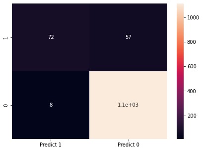

```python
cm=metrics.confusion_matrix(y1_test, y1_predict, labels=[1, 0])

df_cm = pd.DataFrame(cm, index = [i for i in ["1","0"]],
                  columns = [i for i in ["Predict 1","Predict 0"]])
plt.figure(figsize = (7,5))
sns.heatmap(df_cm, annot=True)
```

```python
print("Classification Report") # print evaluation matrix
print(metrics.classification_report(y1_test,y1_predict, labels=[1,0]))
```

```
Classification Report
              precision    recall  f1-score   support

           1       0.90      0.56      0.69       129
           0       0.95      0.99      0.97      1121

    accuracy                           0.95      1250
   macro avg       0.93      0.78      0.83      1250
weighted avg       0.95      0.95      0.94      1250
```

accuracy of model 95 % and precision is also good

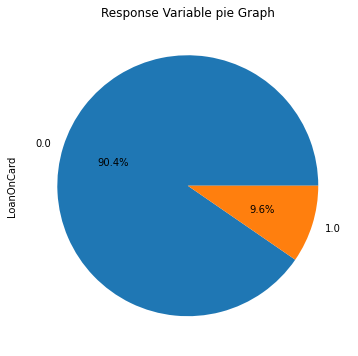

```python
plt.figure(figsize=(8,6))
b_merg['LoanOnCard'].value_counts().plot.pie(autopct='%1.1f%%').set_title('Response Variable pie Graph')
plt.show() # distribution of target variable
```

form the pie chart, data imbalance came into picture, so before training the model further we need to rectify this issue.

```python
b_merg['LoanOnCard'].value_counts()
```

```
0.0    4520
1.0     480
Name: LoanOnCard, dtype: int64
```

```python
b_merg['Mortgage'].value_counts()
```

```
0      3462
98       17
119      16
89       16
91       16
       ...
547       1
458       1
505       1
361       1
541       1
Name: Mortgage, Length: 347, dtype: int64
```

```python
b_merg['HighestSpend'].value_counts()
```

```
44     85
38     84
81     83
41     82
39     81
       ..
202     2
203     2
189     2
224     1
218     1
Name: HighestSpend, Length: 162, dtype: int64
```

```python
b_merg['MonthlyAverageSpend'].value_counts()
```

```
0.30    241
1.00    231
0.20    204
2.00    188
0.80    187
       ...
3.25      1
3.67      1
4.67      1
8.90      1
2.75      1
Name: MonthlyAverageSpend, Length: 108, dtype: int64
```

After checking all 3 significant columns in the data set and getting their value counts, we can keep the data as is. The value counts of outliers are repeating and the values which are having less value counts are with in range (i.e. less then max value)

```python
y1_train.to_frame().value_counts(normalize=True)
```

```
LoanOnCard
0.0           0.9064
1.0           0.0936
dtype: float64
```

```python
y1_test.to_frame().value_counts(normalize=True)
```

```
LoanOnCard
0.0           0.8968
1.0           0.1032
dtype: float64
```

```python
# data balance
```

```python
from imblearn.over_sampling import RandomOverSampler# oversampling
# define oversampling strategy
oversample = RandomOverSampler(sampling_strategy='minority')
# fit and apply the transform
X1_over, y1_over = oversample.fit_resample(X1_train, y1_train)
print("Number of records oversample Data X: ", X1_over.shape)
print("Number of records oversample Data y: ", y1_over.shape)
print("Number of records split train Data X: ", X1_train.shape)
print("Number of records split train Data y: ", y1_train.shape)
```

```
Number of records oversample Data X:  (6798, 7)
Number of records oversample Data y:  (6798,)
Number of records split train Data X:  (3750, 7)
Number of records split train Data y:  (3750,)
```

```python
from sklearn import metrics

from sklearn.linear_model import LogisticRegression

# Fit the model on train
model = LogisticRegression(solver="liblinear")
model.fit(X1_over, y1_over)
#predict on test
y1_predict = model.predict(X1_test)


coef_df = pd.DataFrame(model.coef_)
coef_df['intercept'] = model.intercept_
print(coef_df)
```

```
          0         1         2         3         4         5         6  \
0  0.050967  0.520826  0.225381  1.254092  0.000537 -0.907358  2.766716

   intercept
0 -10.191668
```

```python
model_score = model.score(X1_test, y1_test)
print(model_score)
```

```
0.8936
```

```python
print("Classification Report,oversampling")
print(metrics.classification_report(y1_test,y1_predict, labels=[1,0]))
```

```
Classification Report,oversampling
              precision    recall  f1-score   support

           1       0.49      0.88      0.63       129
           0       0.99      0.89      0.94      1121

    accuracy                           0.89      1250
   macro avg       0.74      0.89      0.78      1250
weighted avg       0.93      0.89      0.91      1250
```

```python
from imblearn.datasets import make_imbalance # balance data using under sampling
```

```python
b_merg['LoanOnCard'].value_counts()
```

```
0.0    4520
1.0     480
Name: LoanOnCard, dtype: int64
```

```python
X2 = b_merg.drop(labels= ["ID",'ZipCode','Age', 'CustomerSince', 'InternetBanking','CreditCard','LoanOnCard'],axis = 1)
y2 = b_merg["LoanOnCard"]
X2.head()
```

|  | HighestSpend | HiddenScore | MonthlyAverageSpend | Level | Mortgage | Security | FixedDepositAccount |
| --- | --- | --- | --- | --- | --- | --- | --- |
| 0 | 49 | 4 | 1.6 | 1 | 0 | 1 | 0 |
| 1 | 34 | 3 | 1.5 | 1 | 0 | 1 | 0 |
| 2 | 11 | 1 | 1.0 | 1 | 0 | 0 | 0 |
| 3 | 100 | 1 | 2.7 | 2 | 0 | 0 | 0 |
| 4 | 45 | 4 | 1.0 | 2 | 0 | 0 | 0 |

```python
X2_train, X2_test, y2_train, y2_test = train_test_split(X2, y2, test_size=0.25, random_state=1)
```

```python
X2_train, y2_train = make_imbalance(X2_train, y2_train, sampling_strategy={0: 351},random_state=1) # under sampling
```

```python
y2_train.value_counts()
```

```
0.0    351
1.0    351
Name: LoanOnCard, dtype: int64
```

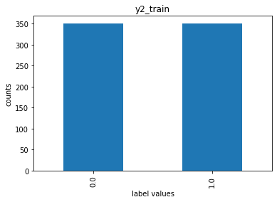

```python
y2_train.value_counts().plot(kind='bar')
plt.title('y2_train')
plt.xlabel('label values')
plt.ylabel('counts')
plt.show()
```

```python
# Fit the model on train
model = LogisticRegression(solver="liblinear")
model.fit(X2_train, y2_train)
#predict on test
y2_predict = model.predict(X2_test)


coef_df = pd.DataFrame(model.coef_)
coef_df['intercept'] = model.intercept_
print(coef_df)
```

```
          0         1         2         3         4         5         6  \
0  0.036253  0.233552  0.248832  0.740107 -0.000612 -1.015042  2.207083

   intercept
0  -6.693783
```

```python
model_score = model.score(X2_test, y2_test)
print(model_score)
```

```
0.8824
```

```python
print("Classification Report,undersampling")
print(metrics.classification_report(y2_test,y2_predict, labels=[1,0]))
```

```
Classification Report,undersampling
              precision    recall  f1-score   support

           1       0.46      0.88      0.61       129
           0       0.99      0.88      0.93      1121

    accuracy                           0.88      1250
   macro avg       0.72      0.88      0.77      1250
weighted avg       0.93      0.88      0.90      1250
```

4. Performance Improvement: [10 Marks] A. Train a base model each for SVM, KNN. [4 Marks] B. Tune parameters for each of the models wherever required and finalize a model. [3 Marks] (Optional: Experiment with various Hyperparameters - Research required) C. Print evaluation metrics for final model. [1 Marks] D. Share improvement achieved from base model to final model. [2 Marks

```python
#SVM model training for base model
```

```python
from sklearn import svm
from sklearn.svm import SVC
```

```python
X3 = b_merg.drop(labels= ["ID",'ZipCode','Age', 'CustomerSince', 'InternetBanking','CreditCard','LoanOnCard'],axis = 1)
y3 = b_merg["LoanOnCard"]
X3.head()
```

|  | HighestSpend | HiddenScore | MonthlyAverageSpend | Level | Mortgage | Security | FixedDepositAccount |
| --- | --- | --- | --- | --- | --- | --- | --- |
| 0 | 49 | 4 | 1.6 | 1 | 0 | 1 | 0 |
| 1 | 34 | 3 | 1.5 | 1 | 0 | 1 | 0 |
| 2 | 11 | 1 | 1.0 | 1 | 0 | 0 | 0 |
| 3 | 100 | 1 | 2.7 | 2 | 0 | 0 | 0 |
| 4 | 45 | 4 | 1.0 | 2 | 0 | 0 | 0 |

```python
X3_train, X3_test, y3_train, y3_test = train_test_split(X3, y3, test_size=0.25, random_state=1)
```

```python
clf = svm.SVC(gamma=0.025, C=3)
```

```python
clf.fit(X3_train , y3_train)
```

```
SVC(C=3, gamma=0.025)
```

```python
y3_pred = clf.predict(X3_test)
```

```python
model_score = model.score(X3_test, y3_test)
print(model_score)
```

```
0.8824
```

```python
#KNN
```

```python
 #Train a Supervised Learning Classification base model using KNN classifier.

knn1 = KNeighborsClassifier(n_neighbors= 5 , weights = 'distance', leaf_size=30, p=2) # default values of n_neighbors, p and leaf_size taken into consideratio
```

```python
knn1.fit(X3_train, y3_train)
```

```
KNeighborsClassifier(weights='distance')
```

```python
knn1.score(X3_train, y3_train)
```

```
1.0
```

```python
predicted_labels = knn1.predict(X3_test)
knn1.score(X3_test, y3_test)
```

```
0.9192
```

```python
#SVM hyperparamter tuning
```

```python
#hyper parameter tuning (SVM model)
# defining parameter range
param_grid = {'C': [0.1, 1, 10, 100, 1000],
              'gamma': [1, 0.1, 0.01, 0.001, 0.0001],
              'kernel': ['rbf']}

grid = GridSearchCV(SVC(), param_grid, refit = True, verbose = 3)

# fitting the model for grid search
grid.fit(X3_train, y3_train)
```

[output not shown]

[output cut: 71 more lines]

[output not shown]

```
GridSearchCV(estimator=SVC(),
             param_grid={'C': [0.1, 1, 10, 100, 1000],
                         'gamma': [1, 0.1, 0.01, 0.001, 0.0001],
                         'kernel': ['rbf']},
             verbose=3)
```

```python
# print best parameter after tuning
print(grid.best_params_)

# print how our model looks after hyper-parameter tuning
print(grid.best_estimator_)
```

```
{'C': 1000, 'gamma': 0.0001, 'kernel': 'rbf'}
SVC(C=1000, gamma=0.0001)
```

```python
clf = svm.SVC(gamma=0.0001, C=1000)
```

```python
clf.fit(X3_train , y3_train)
```

```
SVC(C=1000, gamma=0.0001)
```

```python
y3_pred = clf.predict(X3_test)
```

```python
model_score = model.score(X3_test, y3_test)
print(model_score)
```

```
0.8824
```

```python
# knn parameter tuning
```

```python
scores=[]
for k in range(1,50):
    knn_4= KNeighborsClassifier(n_neighbors= k, weights= 'distance')
    knn_4.fit(X3_train, y3_train)
    scores.append(knn_4.score(X3_test, y3_test))
```

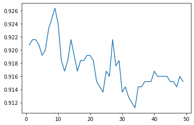

```python
plt.plot(range(1,50),scores)
```